# Educational Measurement as an AI-Native Profession – Educational Measurement as an AI-Native Profession — moderator

## Educational Measurement as an AI-Native Profession

AIME-Con 2026 · Panel · Wednesday 7 October, 11:00–12:30 · Commonwealth 2

**Session chair** Damian Betebenner, Center for Assessment  
**Moderator** lain, an AI interlocutor under the chair’s supervision  
**Discussant** Fred Oswald, University of California, Irvine

**Panelists**  
Derek Briggs, University of Colorado Boulder  
Frank Rijmen, Cambium Assessment  
Mohammed A. A. Abulela, MetaMetrics / University of Minnesota  
Damian Betebenner, Center for Assessment

[figure not shown]

**Panel materials**  
dbetebenner.github.io/AIME_2026_Panel_Presentation

A correction to the printed program: it lists a human moderator. Today the moderator is lain, an AI, under the session chair, and Fred Oswald is our discussant.

## What this conference is about

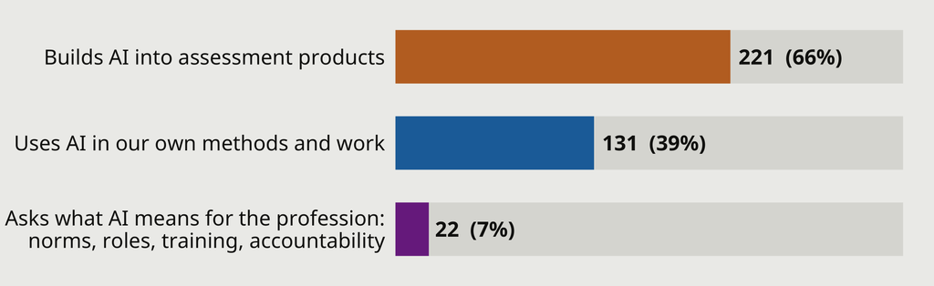

Of the 335 items in the printed program, **66%** build AI into what we deliver and **39%** already use AI in how we work. **22 items (7%)** ask what that means for the profession itself.

Rows overlap: each item was coded on three independent yes/no questions by an AI coder, and a blind second AI coder on a stratified sample of 98 agreed on 91%, 97% and 94% (κ 0.80, 0.94, 0.72). Audited by the chair. Data, prompts and agreement: the materials site.

## The provocation

At this conference: products **221** · our methods **131** · the profession itself **22** (of 335 items).

The chair’s conjecture: an independent order-of-magnitude claim, not estimated from the program coding

How measurement professionals use AI in **their own work** will have **10×** the impact of the AI we build into assessments.

**AI in the product** changes one tool: a scoring engine, an item pool, a tutor.

**AI in the profession** changes every analysis, model, review, document, and decision, including how the next generation of those products is designed, validated, and governed.

## Why a profession-level response

The mathematics community has begun asking this explicitly. The [*Leiden Declaration on AI and Mathematics*](https://leidendeclaration.ai/) (June 2026, endorsed by the IMU; [leidendeclaration.ai](https://leidendeclaration.ai/)) asks the discipline to protect the verifiability of proof, attribution, authorship, and the primacy of human judgment.

**Five guiding questions**

1. **What has changed** in the substance and organization of measurement work?
2. **What that demands of professionals**: the division of labor, expertise, and training.
3. **What the profession must redefine**: what is verified, documented, and disclosed.
4. **What measurement science owes the evaluation of AI**, including this panel.
5. **Where authority and accountability remain human**, and on what grounds.

## Meet lain

An experiment in AI-native educational measurement

lain is our attempt to show what AI-native educational measurement could look like: in this room, not on a slide.

Its evidence is bounded to the panelists’ materials and what is said in this room, with no open web. Like any language model it carries pretrained knowledge, but it may not present that as evidence: a source claim needs a citation, a claim from the room needs a timestamp, and anything else is labeled inferred. Its authority belongs to the chair. Everything it proposes, including what it is not allowed to say, goes on the record.

**As AI becomes more capable, one of the most important things professionals do is this: gather, deliberate in public, and decide what counts as warranted.**

A session like this one can leave more than memories. The materials, the claims, the disagreements and the norms are collected into a record that future colleagues, and the AI systems they work with, can query, for example through MCP or other AI connectors.

## How lain takes part

**Presence: continuous, visual, silent**

A running record on screen: claims and who made them, sources, agreements, open tensions, question coverage.

**Voice: rare, typed, human-approved**

About 8–12 interventions in 90 minutes, each approved by the chair.

OBSERVE  
↓ chair enables proposals  
PROPOSE  
↓ chair approves one intervention  
SPEAK  
↓ delivered; the permission expires  
Emergency stop → OBSERVE, at once

Every contribution is tagged **observed** (the transcript records someone saying it, with a time), **retrieved** (in a panelist’s material, with the source), or **inferred** (lain’s own reasoning, possibly wrong). Its evidence: the panelists’ materials and the transcript; no open web. It **abstains** when someone else holds the warrant.

## If the technology fails

| State | What it means |
| --- | --- |
| GREEN | Live transcription and running record; approved interventions spoken in lain’s voice |
| AMBER | Same, but I read approved interventions aloud |
| YELLOW | Transcription or analysis degraded; the record freezes at its last good state |
| RED | A conventional panel: same questions, same norm-building |

**Running today:** I’ll tell you which state we’re in, and I will call every change of state aloud. The panel’s argument does not depend on lain working.

## Before we start

**This session is being recorded and transcribed.**  
lain, an AI moderator, speaks aloud under the session chair, who approves every sentence. The transcript and the session record are published afterwards. Questions, typed or asked aloud, become part of that record. No names or emails are collected.

The record includes the full intervention log, **including what lain proposed and I declined**. Panelists review it before release.

[figure not shown]

**Follow along · ask a question**  
or open it from the materials site

[figure not shown]

**Panel materials**  
dbetebenner.github.io/AIME_2026_Panel_Presentation

## Run of show

| Minutes | Segment | lain |
| --- | --- | --- |
| 0–6 | Framing and the AI design | visible, silent |
| 6–26 | Four five-minute provocations: one claim, one example, one unresolved problem | OBSERVE |
| 26–31 | AI synthesis: convergence, disagreement, connections | one approved intervention |
| 31–43 | Discussant: Fred Oswald critiques the panel **and** the AI synthesis | OBSERVE |
| 43–76 | Panel and audience dialogue | PROPOSE; approved SPEAK |
| 76–87 | Norm-building: activity · conditions for AI involvement · who is answerable | PROPOSE |
| 87–90 | Human closing synthesis | silent |